# BaSiC-simulation-comparison

Wei Sun

2019-10-01

This R markdown file illustrate the usage of R package `basic` using simulated data, as described in our paper: Sun et al. (2019) Joint Analysis of Single Cell and Bulk Tissue Sequencing Data to Infer Intra-Tumor Heterogeneity. Here we evaluate two alternative methods: B-SCITE and PhyloWGS.

```r
library(basic)
library(ggcorrplot)
library(gridExtra)
library(knitr)
library(reticulate)
library(Rgraphviz)
```

## B-SCITE

### Prepare input for B-SCITE

We first loaded the simulated data and prepare input for B-SCITE. Because B-SCITE does not take into account of copy number information, we only evaluate it using the data without copy number alterations. The input scDNA-seq data is saved in a text file as a binary matrix with each row being a mutation and each column being a cell.

```r
load("basic/data/simulation_SCS_bulk.RData")

mutations = simu.SCS$observed.mutation
dim(mutations)
```

```
## [1] 1000   20
```

```r
mutations[1:2,1:3]
```

```
##      [,1] [,2] [,3]
## [1,]   NA    1    1
## [2,]    0    0    1
```

```r
table(c(mutations), useNA="ifany")
```

```
##
##    0    1 <NA>
## 5586 7781 6633
```

```r
mutations[which(is.na(mutations))] = 3
table(c(mutations), useNA="ifany")
```

```
##
##    0    1    3
## 5586 7781 6633
```

```r
write.table(mutations, file = "data/B-SCITE_SCFile_n_1000_m_20.txt",
            append = FALSE, quote = FALSE, sep = "\t",
            row.names = FALSE, col.names = FALSE)
```

The input bulk tumor data is saved in a text file with each row being one mutation.

```r
b.trec  = simu.bulk$trec
b.asrec = simu.bulk$asrec
n = length(b.trec)

bulk = data.frame(ID=paste0("mut", 1:n), Chromosome=rep(1,n), Position=1:n)
bulk$MutantCount = b.asrec
bulk$ReferenceCount = b.trec - b.asrec
bulk$INFO = paste0("ID=mut", 1:n, ";")

dim(bulk)
```

```
## [1] 1000    6
```

```r
bulk[1:2,]
```

[output not shown]

```r
write.table(bulk, file = "data/B-SCITE_bulkFile_n_1000.txt",
            append = FALSE, quote = FALSE, sep = "\t",
            row.names = FALSE, col.names = TRUE)
```

B-SCITE is designed for more detailed studies of a small number of mutations because it searches all the possible mutation trees and the number of mutation trees increases super-exponentially with the number of mutations. Therefore analyzing 1000 mutations is computational challenging of B-SCITE. In our experience, running B-SCITE for 1000 mutations will take more than 3 days and the results can be unstable across runs. So we generate a smaller dataset by randomly sample 100 mutations.

```r
set.seed(2020)
s100 = sort(sample(nrow(mutations), 100))

write.table(mutations[s100,], file = "data/B-SCITE_SCFile_n_100_m_20.txt",
            append = FALSE, quote = FALSE, sep = "\t",
            row.names = FALSE, col.names = FALSE)

write.table(bulk[s100,], file = "data/B-SCITE_bulkFile_n_100.txt",
            append = FALSE, quote = FALSE, sep = "\t",
            row.names = FALSE, col.names = TRUE)
```

### Run BaSiC

We first run BaSiC on this sub-sampled dataset

```r
b.trec    = simu.bulk$trec[s100]
b.asrec   = simu.bulk$asrec[s100]
b.cn      = rep(2, length(b.trec))

mutations = simu.SCS$observed.mutation[s100,]
trec      = simu.SCS$trec[s100,]
asrec     = simu.SCS$asrec[s100,]

cBSC = cluster.BSC(b.cn, b.asrec, b.trec, mutations, asrec, trec, nclusters=2:5)
```

```
## initialize mutation calls in single cells
```

```
## nclust = 2, time: Tue Oct  1 22:30:58 2019
```

```
## nclust = 3, time: Tue Oct  1 22:31:05 2019
```

```
## nclust = 4, time: Tue Oct  1 22:31:08 2019
```

```
## nclust = 5, time: Tue Oct  1 22:31:09 2019
```

```r
cBSC$summary.cluster
```

```
##    nclust      AIC      BIC  nIt
## n2      2 5560.457 5797.744 1000
## n3      3 5555.535 5917.115  355
## n4      4 5517.739 6003.613  155
## n5      5 5344.987 5955.154  121
```

```r
n1 = sum(s100 <= 600)
n2 = sum(s100 <= 800) - n1
n3 = sum(s100 <= 900) - n1 - n2
n4 = length(s100) - n1 - n2 - n3
c(n1, n2, n3, n4)
```

```
## [1] 61 17  9 13
```

```r
mut.cluster.true  = c(rep(1,n1), rep(2,n2), rep(3,n3), rep(4,n4))
mut.cluster.basic = apply(cBSC$n5$postPs, 1, which.max)
table(mut.cluster.true, mut.cluster.basic)
```

```
##                 mut.cluster.basic
## mut.cluster.true  1  2  3  4  5
##                1 20 40  1  0  0
##                2  2  4 10  1  0
##                3  0  0  0  0  9
##                4  0  0  0 13  0
```

The results of BaSiC is more accurate (e.g., identify 4 instead of 5 clusters) when we use all 1000 mutations. See the file `ex_simulation.html` for more details. Here we illustrate the mutation data. The observed mutations is indeed very noisy.

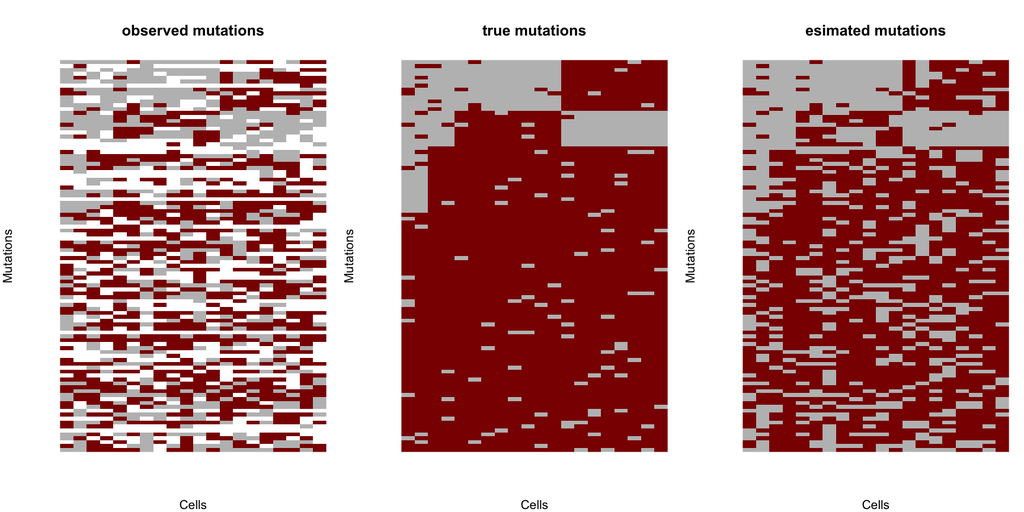

```r
Ds = mutations
Es = simu.SCS$true.mutations[s100,]

par(mfrow=c(1,3), mar=c(4,4,4,1))
image(t(Ds), col=c("grey", "darkred"), axes = FALSE, xlab="Cells",
      ylab="Mutations", main="observed mutations")
image(t(Es), col=c("grey", "darkred"), axes = FALSE, xlab="Cells",
      ylab="Mutations", main="true mutations")
image(t(cBSC$n5$E), col=c("grey", "darkred"), axes = FALSE, xlab="Cells",
      ylab="Mutations", main="esimated mutations")
```

### Run B-SCITE

We downloaded the B-SCITE package from https://github.com/smalikic/B-SCITE. Then we compiled it following the instruction at https://github.com/smalikic/B-SCITE, and ran the analysis using command `python run_B-SCITE.py`. We modified the code `run_B-SCITE.py` for our analysis to update the path for input files. In addition, we changed the line of `run_command += "-SCFileLocation " + SCFile + " "` to be `run_command += "-i " + SCFile + " "`. This is because in the cpp source code, the single cell data file is provided through `-i`. Without this update, we encountered an error message `unknown parameter -SCFileLocation`.

```python
import sys
import os

APP_PATH  =  "./../src/bscite.exe" # path to B-SCITE executable
OUTPUT_FOLDER = "./basic_simulation" # this is the prefix used for the three output files (.matrices, .gv and .newick) given as the output of B-SCITE

SCFile   = "./B-SCITE_SCFile_n_100_m_20.txt" # path input SC File
bulkFile = "./B-SCITE_bulkFile_n_100.txt"    # path input bulk file
fp = 0.00001 # estimated false positive rate of SCS experiment
fn = 0.15    # estimated false negative rate of SCS experiment
n  = 100     # number of mutations
m  = 20      # number of cells
r  = 1       # number of repeats
l  = 2000    # number of loops

run_command =""
run_command += APP_PATH + " "
run_command += "-i "   + SCFile   + " "
run_command += "-bulkFileLocation " + bulkFile + " "
run_command += "-n "  + str(n)  + " "
run_command += "-m "  + str(m)  + " "
run_command += "-fd " + str(fp) + " "
run_command += "-ad " + str(fn) + " "
run_command += "-r "  + str(r)  + " "
run_command += "-l "  + str(l)  + " "
run_command += "-o "  + OUTPUT_FOLDER + " "
os.system(run_command)
```

### Summarize B-SCITE results

Here we summarize the results of B-SCITE by a plot. The correct cluster is 1-61, 62-78, 79-87, and 88-100. It is apparent that B-SCITE does not capture the correct cluster accurately.

```r
cumsum(c(n1, n2, n3, n4))
```

```
## [1]  61  78  87 100
```

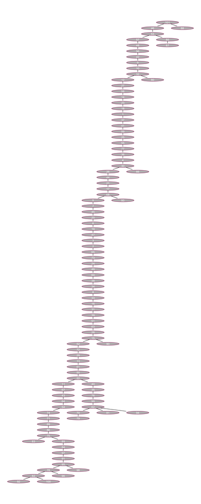

```r
g1 = agread("data/basic_simulation_100_ml0.gv")
cols = rep(c("lightblue", "grey", "lightyellow", "lightgreen"),
           times=c(n1,n2,n3,n4))
names(cols) = 1:100
plot(g1, nodeAttrs=list(fillcolor=cols))
```

## PhyloWGS

```r
bulk2 = data.frame(id=paste0("s", 0:(n-1)), gene=paste0("gene", 0:(n-1)))
bulk2$a = b.trec-b.asrec
bulk2$d = b.trec
bulk2$mu_r = rep(0.999, n)
bulk2$mu_v = rep(0.499, n)

dim(bulk2)
```

```
## [1] 1000    6
```

```r
bulk2[1:2,]
```

```
##   id  gene  a   d  mu_r  mu_v
## 1 s0 gene0 60 104 0.999 0.499
## 2 s1 gene1 44  66 0.999 0.499
```

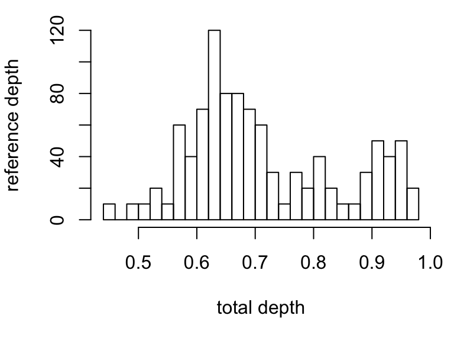

```r
par(mar=c(5,4,1,1))
hist(bulk2$a/bulk2$d, xlab="total depth", ylab="reference depth",
     breaks=20, main="")
```

```r
write.table(bulk2, file = "data/PhyloWGS_ssm_data.txt",
            append = FALSE, quote = FALSE, sep = "\t",
            row.names = FALSE, col.names = TRUE)

if(file.exists("data/PhyloWGS_cnv_data.txt")){ system("rm data/PhyloWGS_cnv_data.txt") }
system("touch data/PhyloWGS_cnv_data.txt")
```

### Run PhyloWGS

We used the following shell script to run PhyloWGS. First copy the files `PhyloWGS_ssm_data.txt` and `PhyloWGS_cnv_data.txt` to a working directory and run the fillowing shell script in the working directory.

```bash
#!/bin/sh

echo 'Run PhyloWGS ...'

python ~/research/ITH/_software/phylowgs/multievolve.py \
--num-chains 4 \
--ssms PhyloWGS_ssm_data.txt \
--cnvs PhyloWGS_cnv_data.txt

cd chains

[ ! -d test_results ] && mkdir test_results
cd test_results

echo 'Summarize PhyloWGS result ...'

python ~/research/ITH/_software/phylowgs/write_results.py \
--include-ssm-names \
--min-ssms 2 \
example_data ../trees.zip \
example_data.summ.json.gz \
example_data.muts.json.gz \
example_data.mutass.zip

cd ..
cp -r test_results ~/research/ITH/_software/phylowgs/witness/data
cd ~/research/ITH/_software/phylowgs/witness
gunzip data/*/*.gz
python index_data.py
python -m SimpleHTTPServer
```

Then the results can be viewed from http://127.0.0.1:8000 in your browser. Here are a few screenshots of the results. The first plot shows the phylogenetic tree. As expected, PhyloWGS identify three subclones and cannot separate the two subclones with very similar cellular frequencies. Here simulated subclone 3 and 4 were combined into subclone 3.

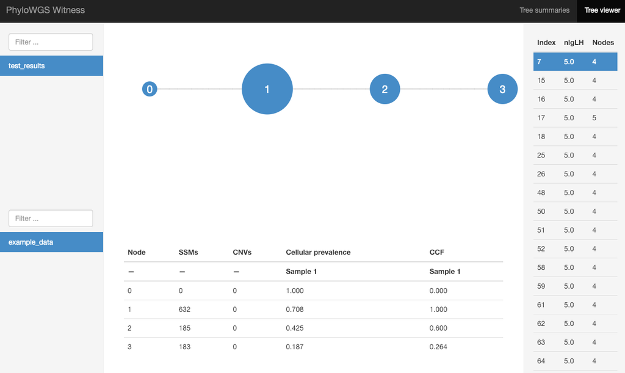

Next plot shows the the number of subclones across all trees sampled by PhyloGWS’s MCMC. In most cases, 3 subclones were found.

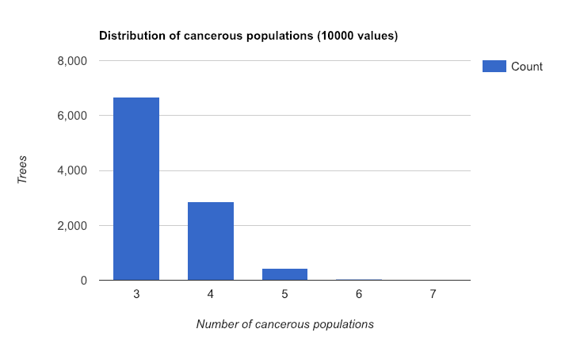